# Matching using R pt.2

Meng Le Zhang

March 3, 2022

# Matching

- Assumption: You observe all confounders $X$
- Goal: Match treatment cases with similar control cases based on $X$ (avoid colliders)
- Ideal outcome: Distribution of $X$ is identical between treatment and control groups (balanced)

## Matching steps

- 0. Omit the outcome variable from the data. Pick your $X$ based on design.
- 1. Defining “closeness”: the distance measure used to determine whether an individual is a good match for another,
- 2. Implementing a matching method, given that measure of closeness,
- 3. Assessing the quality of the resulting matched samples, and perhaps iterating with Steps (1) and (2) until well-matched samples result, and
- 4. Analysis of the outcome and estimation of the treatment effect, given the matching done in Step (3).

# Advantages over just regression

- Why not just use [insert model here]?
- Most modelling approaches assume:
  - 1. all confounders are observed
  - 2. the model is correct

## Advantages over just regression

- ‘Wrong’ models (e.g. wrong functional form) can still give the right results if:
  - the treatment and control group have identical characteristics (treatment is uncorrelated with confounders)
- Balancing the sample beforehand guards against incorrect models

## Advantages over just regression

- Matching doesn’t always work perfectly (some imbalance)
- Modelling can fill in the gaps (so long as extrapolation error is reasonable)

## Doubly robust example

- Linear regression: wage = treat + maths
- Treatment effect: - 88 (SE: 13.8) [Real effect = 0]

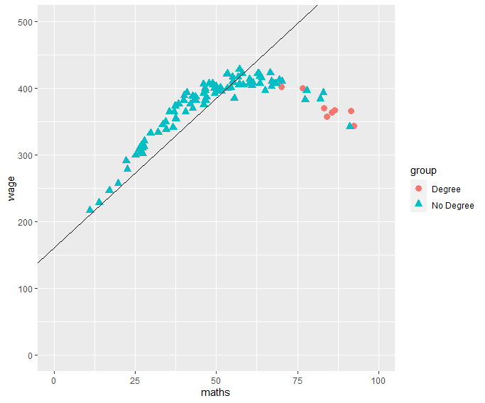

## Doubly robust example

- Linear regression: wage = treat + maths
- Estimated diff: -0.66 (SE: 7.78) [Real effect = 0]

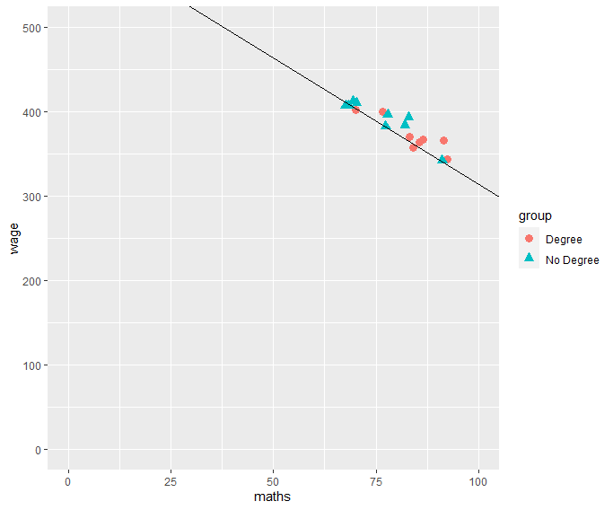

# MatchIt (R package)

- Suite of matching functions for matching
- Collects various functions from other packages as well
- Fantastic documentation: `use vignette('MatchIt')`

Daniel E. Ho, Kosuke Imai, Gary King, Elizabeth A. Stuart (2011). MatchIt: Nonparametric Preprocessing for Parametric Causal Inference. Journal of Statistical Software, Vol. 42, No. 8, pp. 1-28. https://doi.org/10.18637/jss.v042.i08

# Step zero: Avoid data mining

- Pick your matching covariates $X$ based on your design
- Ground your choices in facts not convenient assumptions
- Take your outcome variable out of the data before matching